# chapter3

Abushahba

November 22, 2017

# Logistic regression

Here we will practice some priciples of **logistic regression** using the joined student alcohol consumption data, let’s have a look on that

```r
analys3 <-read.csv("C:/Users/ahmed/Desktop/IODS-project/data/joined data set for analysis.csv")

glimpse(analys3)
```

```
## Observations: 382
## Variables: 36
## $ X          <int> 1, 2, 3, 4, 5, 6, 7, 8, 9, 10, 11, 12, 13, 14, 15, ...
## $ ï..school  <fctr> GP, GP, GP, GP, GP, GP, GP, GP, GP, GP, GP, GP, GP...
## $ sex        <fctr> F, F, F, F, F, M, M, F, M, M, F, F, M, M, M, F, F,...
## $ age        <int> 18, 17, 15, 15, 16, 16, 16, 17, 15, 15, 15, 15, 15,...
## $ address    <fctr> U, U, U, U, U, U, U, U, U, U, U, U, U, U, U, U, U,...
## $ famsize    <fctr> GT3, GT3, LE3, GT3, GT3, LE3, LE3, GT3, LE3, GT3, ...
## $ Pstatus    <fctr> A, T, T, T, T, T, T, A, A, T, T, T, T, T, A, T, T,...
## $ Medu       <int> 4, 1, 1, 4, 3, 4, 2, 4, 3, 3, 4, 2, 4, 4, 2, 4, 4, ...
## $ Fedu       <int> 4, 1, 1, 2, 3, 3, 2, 4, 2, 4, 4, 1, 4, 3, 2, 4, 4, ...
## $ Mjob       <fctr> at_home, at_home, at_home, health, other, services...
## $ Fjob       <fctr> teacher, other, other, services, other, other, oth...
## $ reason     <fctr> course, course, other, home, home, reputation, hom...
## $ nursery    <fctr> yes, no, yes, yes, yes, yes, yes, yes, yes, yes, y...
```

[output cut: 23 more lines]

This data approach student achievement in secondary education of two Portuguese schools. The data (in the two sets) attributes include student grades, demographic, social and school related features and it was collected by using school reports and questionnaires, more details can be found [*here*](https://archive.ics.uci.edu/ml/datasets/Student+Performance), I have performed some data wrangling to Keep only the students present in both data sets, combine the ‘duplicated’ answers in the joined data, take the average of the answers related to weekday and weekend alcohol consumption and create a new logical column ‘high_use’ which is TRUE for students for which ‘alc_use’ is greater than 2 (and FALSE otherwise), and the Rscript for that can be found [*here*](https://github.com/Abushahba/IODS-project/blob/master/data/create_alc.R)

## The purpose

The purpose of analysis is to study the relationships between high/low alcohol consumption and some of the other variables in the data. To do this, we choose 4 interesting variables in the data; absences,quality of family relationship, sex (M) and free time after school. We hypthesize that those factors are correlated with higher alchol consumption.

Let’s have a look on that:

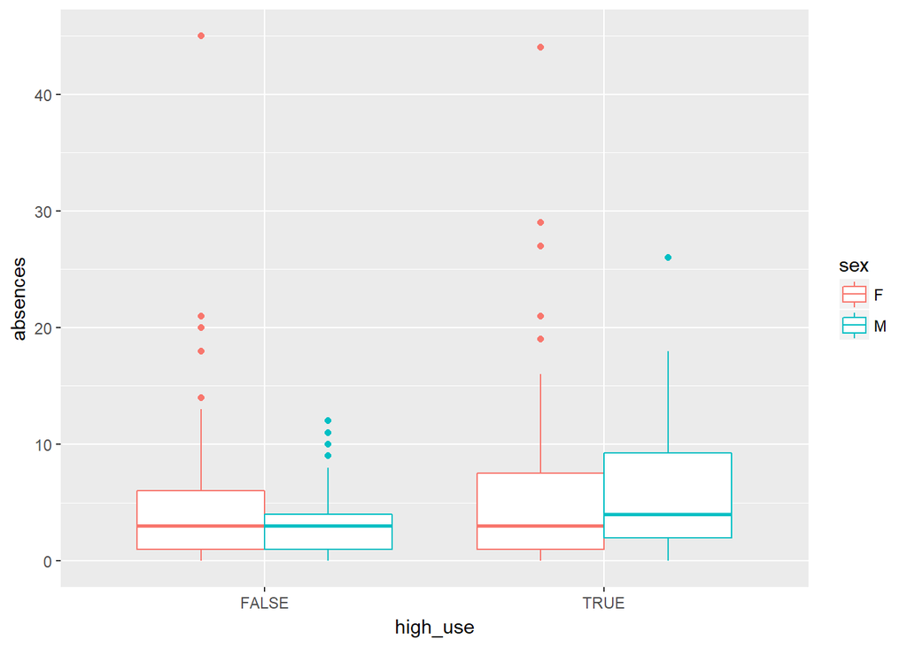

```r
g1 <- ggplot(analys3, aes(x = high_use, y = absences, col = sex))

g1 + geom_boxplot()
```

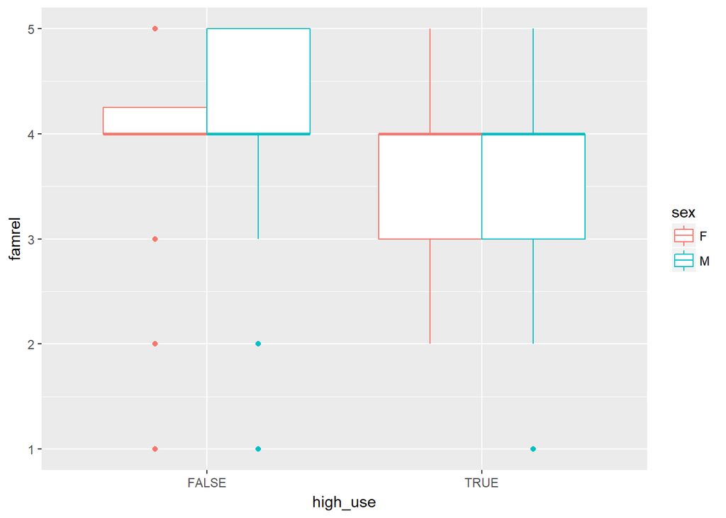

```r
g2 <- ggplot(analys3, aes(x = high_use, y = famrel, col = sex))

g2 + geom_boxplot()
```

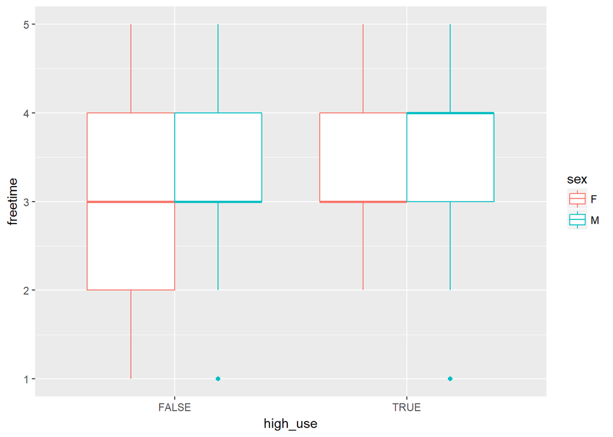

```r
g3 <- ggplot(analys3, aes(x = high_use, y = freetime, col = sex))

g3 + geom_boxplot()
```

```r
analys3 %>% group_by(sex, absences, famrel, high_use) %>% summarise(count = n(), mean_freetime = mean(freetime))
```

```
## # A tibble: 149 x 6
## # Groups:   sex, absences, famrel [?]
##       sex absences famrel high_use count mean_freetime
##    <fctr>    <int>  <int>    <lgl> <int>         <dbl>
##  1      F        0      3    FALSE     2      2.500000
##  2      F        0      3     TRUE     3      3.333333
##  3      F        0      4    FALSE    15      2.933333
##  4      F        0      4     TRUE     2      3.500000
##  5      F        0      5    FALSE    11      2.636364
##  6      F        0      5     TRUE     1      4.000000
##  7      F        1      1    FALSE     1      2.000000
##  8      F        1      2    FALSE     1      3.000000
##  9      F        1      2     TRUE     1      3.000000
## 10      F        1      3    FALSE     6      3.000000
## # ... with 139 more rows
```

## Fitting a model

To statistically test this lets fit logistic regression to explore the relationship between our chosen variables and the binary high/low alcohol consumption variable as the target variable.

```r
m <- glm(high_use ~ absences + sex + famrel + freetime, data = analys3, family = "binomial")

summary(m)
```

```
##
## Call:
## glm(formula = high_use ~ absences + sex + famrel + freetime,
##     family = "binomial", data = analys3)
##
## Deviance Residuals:
##     Min       1Q   Median       3Q      Max
## -1.9125  -0.8195  -0.5923   1.0419   2.0860
##
## Coefficients:
##             Estimate Std. Error z value Pr(>|z|)
## (Intercept) -1.56113    0.62549  -2.496 0.012565 *
## absences     0.09488    0.02244   4.229 2.35e-05 ***
## sexM         0.92271    0.24859   3.712 0.000206 ***
## famrel      -0.34855    0.13181  -2.644 0.008187 **
## freetime     0.33967    0.12673   2.680 0.007358 **
## ---
## Signif. codes:  0 '***' 0.001 '**' 0.01 '*' 0.05 '.' 0.1 ' ' 1
##
## (Dispersion parameter for binomial family taken to be 1)
##
##     Null deviance: 465.68  on 381  degrees of freedom
## Residual deviance: 417.44  on 377  degrees of freedom
## AIC: 427.44
##
## Number of Fisher Scoring iterations: 4
```

so, in the summary of our model we can taste the close correlation between absences, sex variables and higher use of alchol, and less correlation yet present between status of family relatoiship and freetime with higher alchol consumption.

let’s print out the coefficients of the model to use to obtain Odds ratio (OR) and then confidence intervals (CI)

```r
coef(m)
```

```
## (Intercept)    absences        sexM      famrel    freetime
## -1.56112511  0.09487753  0.92270514 -0.34854597  0.33967147
```

```r
OR <- coef(m) %>% exp()

CI <- confint(m) %>% exp()
cbind(OR, CI)
```

```
##                    OR     2.5 %    97.5 %
## (Intercept) 0.2098998 0.0600191 0.7022687
## absences    1.0995242 1.0542744 1.1516588
## sexM        2.5160876 1.5542543 4.1270709
## famrel      0.7057135 0.5433500 0.9127012
## freetime    1.4044861 1.0989755 1.8082673
```

## Exploring the predictive power of our model

```r
m <- glm(high_use ~ freetime + absences + sex, data = analys3, family = "binomial")

probabilities <- predict(m, type = "response")

analys3 <- mutate(analys3, probability = probabilities)

analys3 <- mutate(analys3, prediction = (probability > 0.5))

select(analys3, freetime, absences, sex, high_use, probability, prediction) %>% tail(10)
```

```
##     freetime absences sex high_use probability prediction
## 373        3        0   M    FALSE   0.2696155      FALSE
## 374        4        7   M     TRUE   0.4945212      FALSE
## 375        3        1   F    FALSE   0.1449414      FALSE
## 376        4        6   F    FALSE   0.2697703      FALSE
## 377        4        2   F    FALSE   0.1998871      FALSE
## 378        3        2   F    FALSE   0.1574882      FALSE
## 379        2        2   F    FALSE   0.1227034      FALSE
## 380        1        3   F    FALSE   0.1034644      FALSE
## 381        4        4   M     TRUE   0.4218155      FALSE
## 382        4        2   M     TRUE   0.3749754      FALSE
```

```r
table(high_use = analys3$high_use, prediction = analys3$prediction) %>% prop.table() %>% addmargins()
```

```
##         prediction
## high_use      FALSE       TRUE        Sum
##    FALSE 0.66492147 0.03664921 0.70157068
##    TRUE  0.23036649 0.06806283 0.29842932
##    Sum   0.89528796 0.10471204 1.00000000
```

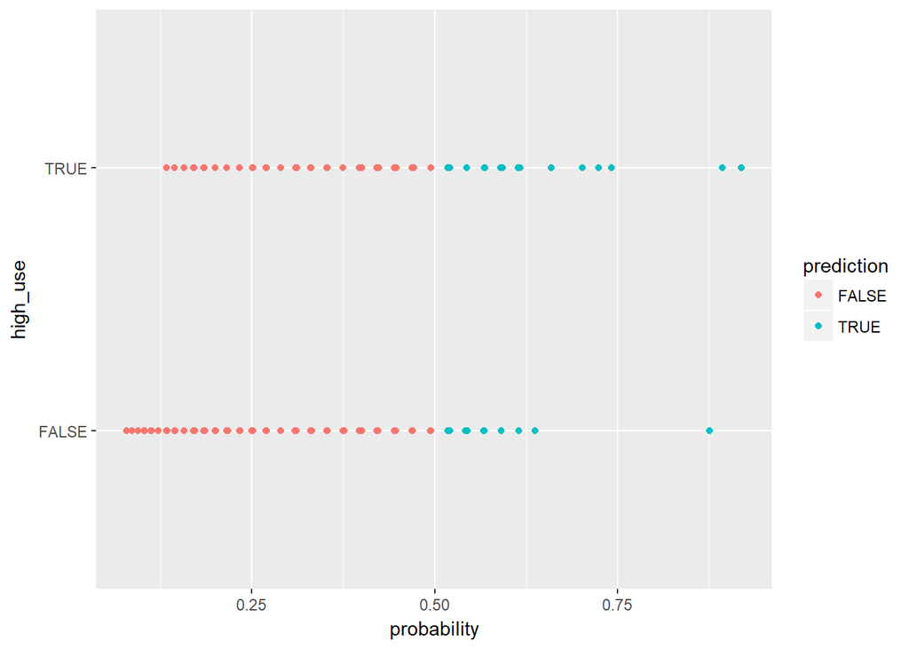

```r
g <- ggplot(analys3, aes(x = probability, y = high_use, col = prediction))

g + geom_point()
```

It is evident that our prediction is not sensitive enough to predict higher alchol consumption; however, it was relatively specific in prdicting lower alchol consumers.

Now, let’s compute the total proportion of inaccurately classified individuals

```r
loss_func <- function(class, prob) {
  n_wrong <- abs(class - prob) > 0.5
  mean(n_wrong)
}

loss_func(class = analys3$high_use, prob = analys3$probability)
```

```
## [1] 0.2670157
```

so, in our model the mean of incorrectly classified observations is around 0.267

## Cross validation

Performing 10-fold cross-validation on our model, compute the average number of wrong predictions in the (training) data, compare to average number of wrong predictions in the cross validation

```r
loss_func <- function(class, prob) {
  n_wrong <- abs(class - prob) > 0.5
  mean(n_wrong)
}

loss_func(class = analys3$high_use, prob = analys3$probability)
```

```
## [1] 0.2670157
```

```r
library(boot)
cv <- cv.glm(data = analys3, cost = loss_func, glmfit = m, K = 10)

cv$delta[1]
```

```
## [1] 0.2748691
```

prediction error higher on the testing data compared to the training data.